# Week 2 Assignment

Emma Colley

9/17/2020

# Redefining Variables

While I kept my overall topic of rent burden in Massachusetts, I changed my variables since last week. In Assignment 1, I was working with household-level data. In Assignment 2 I will be working with person-level data. I did this because there were several person-level categorical variables I was interested in analyzing along side Gross Rent as Percentage of Household Income. So in this study, I am including individuals who live in rent burdened households. All individuals in the sample pay a gross household rent that is 30-100% of their household income. I selected four continuous variables and two categorical variables as shown below.

My biggest hurdle during this assignment was interpreting the histograms. I have no previous experience with statistics and I need to study distributions more closely.

*Continuous*

1. Age of Individual (AGEP)
2. Number of People in Household (NP)
3. Annual Household Income (HINCP)
4. Gross Rent as Percentage of Household Income (GRPIP)

*Categorical*

1. Race/Ethnicity (RAC1P)
2. Highest Level of Education Received (SCHL)

## Loading Libraries

```r
library(tidycensus)
library(tidyverse)
library(ggplot2)
library(ggthemes)
```

## Loading Data

```r
person_data <- read_csv("rent_burden_massachusetts_v2.csv")
```

# Continuous Variables

## Variable 1: Age of Induvidual (AGEP)

```r
summary(person_data$AGEP)
```

```
##    Min. 1st Qu.  Median    Mean 3rd Qu.    Max.
##   18.00   28.00   40.00   44.79   60.00   95.00
```

```r
paste("The sample mean age is",
      prettyNum(mean(person_data$AGEP), digits = 0), "years.")
```

```
## [1] "The sample mean age is 45 years."
```

```r
paste("The sample median age is",
      prettyNum(median(person_data$AGEP), digits = 0), "years.")
```

```
## [1] "The sample median age is 40 years."
```

```r
paste("The sample standard deviation for age is",
      prettyNum(sd(person_data$AGEP), digits = 0), "years.")
```

```
## [1] "The sample standard deviation for age is 19 years."
```

```r
paste("The sample interquartile range for age is",
      quantile(person_data$AGEP)["25%"], "to", quantile(person_data$AGEP)["75%"], "years.")
```

```
## [1] "The sample interquartile range for age is 28 to 60 years."
```

```r
pop_mean <- t.test(person_data$AGEP)
pop_mean
```

```
##
##  One Sample t-test
##
## data:  person_data$AGEP
## t = 166.09, df = 5137, p-value < 2.2e-16
## alternative hypothesis: true mean is not equal to 0
## 95 percent confidence interval:
##  44.25765 45.31494
## sample estimates:
## mean of x
##   44.7863
```

```r
paste("The 95-percent confidence interval for the population mean is",
      prettyNum(pop_mean$conf.int[1], digits = 0), "to",
      prettyNum(pop_mean$conf.int[2], digits = 0), "years.")
```

```
## [1] "The 95-percent confidence interval for the population mean is 44 to 45 years."
```

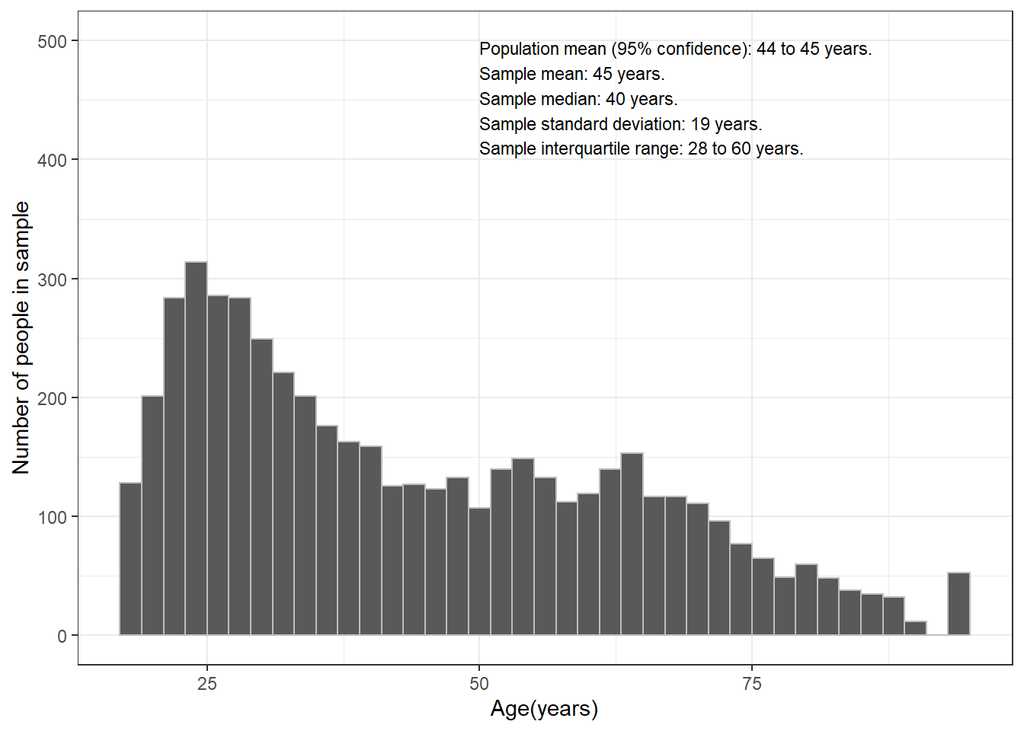

```r
ggplot(person_data, aes(x = person_data$AGEP)) +
  geom_histogram(color = "gray", binwidth = 2) +
  theme_bw() +
  scale_x_continuous(name = "Age(years)") +
  scale_y_continuous(name = "Number of people in sample") +
  annotate("text", x = 50, y = 500, size = 3,
           label = paste("Population mean (95% confidence):",
                         prettyNum(pop_mean$conf.int[1], digits = 0),
                         "to",
                         prettyNum(pop_mean$conf.int[2], digits = 0),
                         "years.",
                         "\nSample mean:",
                         prettyNum(mean(person_data$AGEP), digits = 0), "years.",
                         "\nSample median:",
                         prettyNum(median(person_data$AGEP), digits = 0), "years.",
                         "\nSample standard deviation:",
                         prettyNum(sd(person_data$AGEP), digits = 0), "years.",
                         "\nSample interquartile range:",
                         prettyNum(quantile(person_data$AGEP)["25%"], digits = 0),
                         "to",
                         prettyNum(quantile(person_data$AGEP)["75%"], digits = 0),
                         "years."),
           hjust = 0, vjust = 1)
```

The histogram for age of individual in this sample is fairly uniform but is skewed positively right. More younger people are in this sample. I’m not sure if you can conclude that more young people in Massachusetts live in rent burdened households or just that there are more young people in the larger ACS sample. There appears to be outliers at age 95, perhaps people over the age of 90 were coded at 95 years. I determined this from reviewing Mel Miller’s data.

## Variable 2: Number of People in Household (NP)

```r
summary(person_data$NP)
```

```
##    Min. 1st Qu.  Median    Mean 3rd Qu.    Max.
##   1.000   1.000   2.000   2.441   3.000   9.000
```

```r
paste("The sample mean for the number of people in the household is",
      prettyNum(mean(person_data$NP), digits = 0), "people.")
```

```
## [1] "The sample mean for the number of people in the household is 2 people."
```

```r
paste("The sample median for the number of people in the household is",
      prettyNum(median(person_data$NP), digits = 0), "people.")
```

```
## [1] "The sample median for the number of people in the household is 2 people."
```

```r
paste("The sample standard deviation for the number of people in the household is",
      prettyNum(sd(person_data$NP), digits = 0), "person.")
```

```
## [1] "The sample standard deviation for the number of people in the household is 1 person."
```

```r
paste("The sample interquartile range for the number of people in the household is",
      quantile(person_data$NP)["25%"], "to", quantile(person_data$NP)["75%"], "persons.")
```

```
## [1] "The sample interquartile range for the number of people in the household is 1 to 3 persons."
```

```r
pop_mean <- t.test(person_data$NP)
pop_mean
```

```
##
##  One Sample t-test
##
## data:  person_data$NP
## t = 122.31, df = 5137, p-value < 2.2e-16
## alternative hypothesis: true mean is not equal to 0
## 95 percent confidence interval:
##  2.401712 2.479954
## sample estimates:
## mean of x
##  2.440833
```

```r
paste("The 95-percent confidence interval for the population mean is",
      prettyNum(pop_mean$conf.int[1], digits = 0), "to",
      prettyNum(pop_mean$conf.int[2], digits = 0), "persons.")
```

```
## [1] "The 95-percent confidence interval for the population mean is 2 to 2 persons."
```

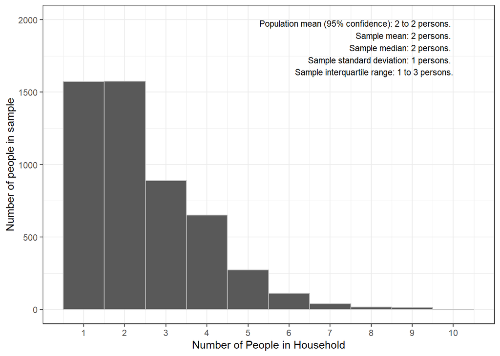

```r
ggplot(person_data, aes(x = person_data$NP)) +
  geom_histogram(color = "gray", binwidth = 1) +
  theme_bw() +
  scale_x_continuous(name = "Number of People in Household", breaks = seq(1, 10, by = 1)) +
  scale_y_continuous(name = "Number of people in sample") +
  annotate("text", x = 10, y = 2000, size = 3,
           label = paste("Population mean (95% confidence):",
                         prettyNum(pop_mean$conf.int[1], digits = 0),
                         "to",
                         prettyNum(pop_mean$conf.int[2], digits = 0),
                         "persons.",
                         "\nSample mean:",
                         prettyNum(mean(person_data$NP), digits = 0), "persons.",
                         "\nSample median:",
                         prettyNum(median(person_data$NP), digits = 0), "persons.",
                         "\nSample standard deviation:",
                         prettyNum(sd(person_data$NP), digits = 0), "persons.",
                         "\nSample interquartile range:",
                         prettyNum(quantile(person_data$NP)["25%"], digits = 0),
                         "to",
                         prettyNum(quantile(person_data$NP)["75%"], digits = 0),
                         "persons."),
           hjust = 1, vjust = 1)
```

This histogram of Number of People in the Household is also skewed positively to the right.I’m not sure if there is a term to describe the initial plateau where the majority of people in this sample live in households with 1 or 2 people; the mean and median are the same. These last conclusions aren’t surprising to me because I am hypothesizing that mostly rent burdened households are in urban areas (Boston).

## Variable 3: Annual Household Income (HINCP)

```r
summary(person_data$HINCP)
```

```
##    Min. 1st Qu.  Median    Mean 3rd Qu.    Max.
##     860   22700   37000   43379   56280  170000
```

```r
paste("The sample mean for annual household income is $",
      prettyNum(mean(person_data$HINCP), digits = 5, na.rm=TRUE))
```

```
## [1] "The sample mean for annual household income is $ 43379"
```

```r
paste("The sample median for annual household income is $",
      prettyNum(median(person_data$HINCP), digits = 5))
```

```
## [1] "The sample median for annual household income is $ 37000"
```

```r
paste("The sample standard deviation for annual household income is $",
      prettyNum(sd(person_data$HINCP), digits = 5))
```

```
## [1] "The sample standard deviation for annual household income is $ 27620"
```

```r
paste("The sample interquartile range for annual household income is $",
      quantile(person_data$HINCP)["25%"], "to $", quantile(person_data$HINCP)["75%"])
```

```
## [1] "The sample interquartile range for annual household income is $ 22700 to $ 56280"
```

```r
pop_mean <- t.test(person_data$HINCP)
pop_mean
```

```
##
##  One Sample t-test
##
## data:  person_data$HINCP
## t = 112.58, df = 5137, p-value < 2.2e-16
## alternative hypothesis: true mean is not equal to 0
## 95 percent confidence interval:
##  42623.71 44134.49
## sample estimates:
## mean of x
##   43379.1
```

```r
paste("The 95-percent confidence interval for the population mean is $",
      prettyNum(pop_mean$conf.int[1], digits = 5), "to $",
      prettyNum(pop_mean$conf.int[2], digits = 5))
```

```
## [1] "The 95-percent confidence interval for the population mean is $ 42624 to $ 44134"
```

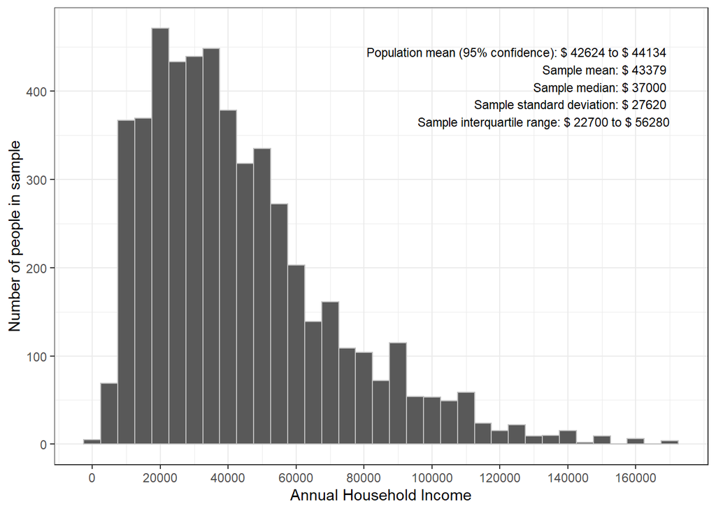

```r
ggplot(person_data, aes(x = person_data$HINCP)) +
  geom_histogram(color = "gray", binwidth = 5000) +
  theme_bw() +
  scale_x_continuous(name = "Annual Household Income", breaks = seq(0, 170000, by = 20000)) +
  scale_y_continuous(name = "Number of people in sample") +
  annotate("text", x = 170000, y = 450, size = 3,
           label = paste("Population mean (95% confidence):",
                         "$", prettyNum(pop_mean$conf.int[1], digits = 5),
                         "to $",
                         prettyNum(pop_mean$conf.int[2], digits = 5),
                         "\nSample mean:",
                         "$", prettyNum(mean(person_data$HINCP), digits = 5),
                         "\nSample median:",
                         "$", prettyNum(median(person_data$HINCP), digits = 5),
                         "\nSample standard deviation:",
                         "$", prettyNum(sd(person_data$HINCP), digits = 5),
                         "\nSample interquartile range:",
                         "$", prettyNum(quantile(person_data$HINCP)["25%"], digits = 5),
                         "to",
                         "$", prettyNum(quantile(person_data$HINCP)["75%"], digits = 5)),
           hjust = 1, vjust = 1)
```

This histogram of Annual Income is also skewed positively to the right. The peak is at $20,000. I believe this is a Poisson distribution. I had to adjust the bin width to produce these results.

## Variable 4: Gross Rent as a Percentage of Household Income (GRPIP)

```r
summary(person_data$GRPIP)
```

```
##    Min. 1st Qu.  Median    Mean 3rd Qu.    Max.
##   30.00   34.00   42.00   47.53   57.00  100.00
```

```r
paste("The sample mean for gross rent as a percentage of household income is",
      prettyNum(mean(person_data$GRPIP), digits = 1), "%.")
```

```
## [1] "The sample mean for gross rent as a percentage of household income is 48 %."
```

```r
paste("The sample median for gross rent as a percentage of household income is",
      prettyNum(median(person_data$GRPIP), digits = 1), "%.")
```

```
## [1] "The sample median for gross rent as a percentage of household income is 42 %."
```

```r
paste("The sample standard deviation for gross rent as a percentage of household income is",
      prettyNum(sd(person_data$GRPIP), digits = 1), "%.")
```

```
## [1] "The sample standard deviation for gross rent as a percentage of household income is 17 %."
```

```r
paste("The sample interquartile range for gross rent as a percentage of household income is",
      quantile(person_data$GRPIP)["25%"], "% to", quantile(person_data$GRPIP)["75%"], "%.")
```

```
## [1] "The sample interquartile range for gross rent as a percentage of household income is 34 % to 57 %."
```

```r
pop_mean <- t.test(person_data$GRPIP)
pop_mean
```

```
##
##  One Sample t-test
##
## data:  person_data$GRPIP
## t = 201.15, df = 5137, p-value < 2.2e-16
## alternative hypothesis: true mean is not equal to 0
## 95 percent confidence interval:
##  47.06887 47.99536
## sample estimates:
## mean of x
##  47.53211
```

```r
paste("The 95-percent confidence interval for the population mean is",
      prettyNum(pop_mean$conf.int[1], digits = 1), "% to",
      prettyNum(pop_mean$conf.int[2], digits = 1), "%.")
```

```
## [1] "The 95-percent confidence interval for the population mean is 47 % to 48 %."
```

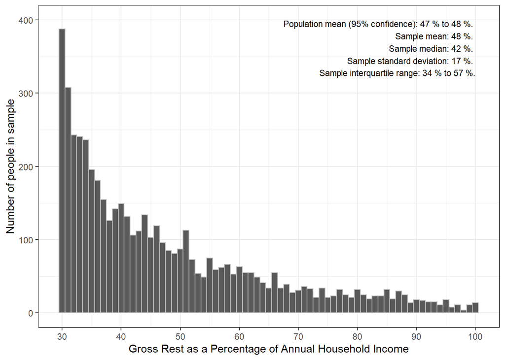

```r
ggplot(person_data, aes(x = person_data$GRPIP)) +
  geom_histogram(color = "gray", binwidth = 1) +
  theme_bw() +
  scale_x_continuous(name = "Gross Rest as a Percentage of Annual Household Income", breaks = seq(30, 100, by = 10)) +
  scale_y_continuous(name = "Number of people in sample") +
  annotate("text", x = 100, y = 400, size = 3,
           label = paste("Population mean (95% confidence):",
                         prettyNum(pop_mean$conf.int[1], digits = 1),
                         "% to",
                         prettyNum(pop_mean$conf.int[2], digits = 1),
                         "%.",
                         "\nSample mean:",
                         prettyNum(mean(person_data$GRPIP), digits = 0), "%.",
                         "\nSample median:",
                         prettyNum(median(person_data$GRPIP), digits = 0), "%.",
                         "\nSample standard deviation:",
                         prettyNum(sd(person_data$GRPIP), digits = 0), "%.",
                         "\nSample interquartile range:",
                         prettyNum(quantile(person_data$GRPIP)["25%"], digits = 0),
                         "% to",
                         prettyNum(quantile(person_data$GRPIP)["75%"], digits = 0),
                         "%."),
           hjust = 1, vjust = 1)
```

This histogram of Gross Rent as a Percentage of Household Income is also skewed positively to the right with a long tail. Would this be a negative binomial distribution? The peak is at 30% of household income being spent on rent. This makes sense, it would be incredibly difficult to live as this percentage increases. Next week, I think I will run this variable with all respondants from 0-100% to see that distribution.

# Categorical Variables

## Variable 5: Race (RAC1P)

```r
race <- unique(person_data$RAC1P_label)
race
```

```
## [1] "White alone"
## [2] "Black or African American alone"
## [3] "American Indian alone"
## [4] "Asian alone"
## [5] "Two or More Races"
## [6] "Some Other Race alone"
## [7] "Native Hawaiian and Other Pacific Islander alone"
## [8] "American Indian and Alaska Native tribes specified; or American Indian or Alaska Native, not specified and no other races"
```

```r
white <- t.test(person_data$RAC1P_label == race[1])
black <- t.test(person_data$RAC1P_label == race[2])
american_indian <- t.test(person_data$RAC1P_label == race[3])
asian <-  t.test(person_data$RAC1P_label == race[4])
two_races <-  t.test(person_data$RAC1P_label == race[5])
other_race <-  t.test(person_data$RAC1P_label == race[6])
native_hawaiian_pacific_islander <-  t.test(person_data$RAC1P_label == race[7])
anerican_indian_alaska_native <-  t.test(person_data$RAC1P_label == race[8])
shares <- tibble(race = c("White",
                            "Black or African American",
                            "American Indian",
                            "Asian",
                            "Two or More Races",
                            "Some Other Race",
                            "Native Hawaiian and Other Pacific Islander",
                            "American Indian and Alaska Native tribes specified"),
                 `Share` = c(white$estimate,
                             black$estimate,
                             american_indian$estimate,
                             asian$estimate,
                             two_races$estimate,
                             other_race$estimate,
                             native_hawaiian_pacific_islander$estimate,
                             anerican_indian_alaska_native$estimate),
                 Low = c(white$conf.int[1],
                         black$conf.int[1],
                         american_indian$conf.int[1],
                         asian$conf.int[1],
                         two_races$conf.int[1],
                         other_race$conf.int[1],
                         native_hawaiian_pacific_islander$conf.int[1],
                         anerican_indian_alaska_native$conf.int[1]),
                 High = c(white$conf.int[2],
                         black$conf.int[2],
                         american_indian$conf.int[2],
                         asian$conf.int[2],
                         two_races$conf.int[2],
                         other_race$conf.int[2],
                         native_hawaiian_pacific_islander$conf.int[2],
                         anerican_indian_alaska_native$conf.int[2]))
knitr::kable(shares, caption = "Proportions and 95-percent confidence intervals")
```

Proportions and 95-percent confidence intervals

| race | Share | Low | High |
| --- | --- | --- | --- |
| White | 0.6915142 | 0.6788810 | 0.7041474 |
| Black or African American | 0.1080187 | 0.0995284 | 0.1165090 |
| American Indian | 0.0013624 | 0.0003535 | 0.0023713 |
| Asian | 0.0809654 | 0.0735041 | 0.0884266 |
| Two or More Races | 0.0404827 | 0.0350918 | 0.0458735 |
| Some Other Race | 0.0770728 | 0.0697777 | 0.0843679 |
| Native Hawaiian and Other Pacific Islander | 0.0001946 | -0.0001869 | 0.0005762 |
| American Indian and Alaska Native tribes specified | 0.0003893 | -0.0001503 | 0.0009288 |

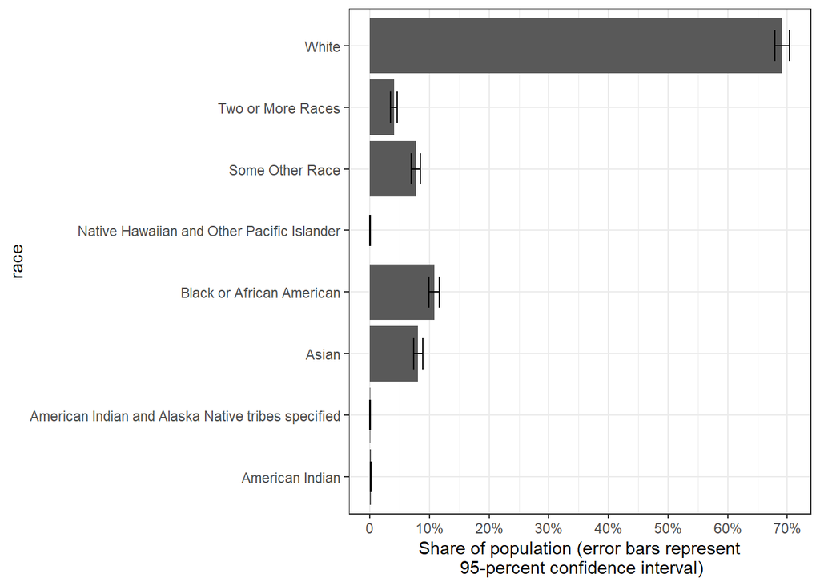

```r
ggplot(shares, aes(x = race, y = Share, ymin = Low, ymax = High)) +
  geom_bar(stat = "identity") +
  coord_flip() +
  geom_errorbar(width = 0.5) +
  theme_bw() +
  scale_x_discrete(labels = c("American Indian",
                            "American Indian and Alaska Native tribes specified",
                            "Asian",
                            "Black or African American",
                            "Native Hawaiian and Other Pacific Islander",
                            "Some Other Race",
                            "Two or More Races",
                            "White")) +
  scale_y_continuous(name = "Share of population (error bars represent\n 95-percent confidence interval)",

                     breaks = c(0, 0.1, 0.2, 0.3, 0.4, 0.5, 0.6, 0.7),
                     labels = c("0", "10%", "20%", "30%", "40%", "50%", "60%", "70%"))
```

## Variable 6: Highest Level of Education (SCHL)

I faced an issue here where my data is not in ascending order (Kindergarten to Doctorate degree.) I could fix this by rearranging the original data. I’m sure there is an alternative solution in the code below that I will seek out this week.

```r
Education <- unique(person_data$SCHL_label)
Education
```

```
##  [1] "Associate's degree"
##  [2] "Grade 11"
##  [3] "Master's degree"
##  [4] "Bachelor's degree"
##  [5] "1 or more years of college credit, no degree"
##  [6] "Regular high school diploma"
##  [7] "GED or alternative credential"
##  [8] "Some college, but less than 1 year"
##  [9] "Grade 6"
## [10] "Doctorate degree"
## [11] "Grade 10"
## [12] "Professional degree beyond a bachelor's degree"
## [13] "Grade 8"
## [14] "Grade 2"
## [15] "No schooling completed"
## [16] "Grade 4"
## [17] "Grade 7"
## [18] "Grade 9"
## [19] "Grade 5"
## [20] "12th grade - no diploma"
## [21] "Grade 3"
## [22] "Grade 1"
## [23] "Kindergarten"
```

```r
associate <- t.test(person_data$SCHL_label == Education[1])
grade_11 <- t.test(person_data$SCHL_label == Education[2])
masters <- t.test(person_data$SCHL_label == Education[3])
bachelors <-  t.test(person_data$SCHL_label == Education[4])
no_degree <-  t.test(person_data$SCHL_label == Education[5])
hs <-  t.test(person_data$SCHL_label == Education[6])
ged <-  t.test(person_data$SCHL_label == Education[7])
some_college <-  t.test(person_data$SCHL_label == Education[8])
grade_6 <-  t.test(person_data$SCHL_label == Education[9])
doctorate <-  t.test(person_data$SCHL_label == Education[10])
grade_10 <-  t.test(person_data$SCHL_label == Education[11])
professional <-  t.test(person_data$SCHL_label == Education[12])
grade_8 <-  t.test(person_data$SCHL_label == Education[13])
grade_2 <-  t.test(person_data$SCHL_label == Education[14])
no_school <-  t.test(person_data$SCHL_label == Education[14])
grade_4 <-  t.test(person_data$SCHL_label == Education[14])
grade_7 <-  t.test(person_data$SCHL_label == Education[14])


shares <- tibble(Education = c("Associate's degree",
                            "Grade 11",
                            "Master's degree",
                            "Bachelor's degree",
                            "1 or more years of college credit, no degree",
                            "Regular high school diploma",
                            "GED or alternative credential",
                            "Some college, but less than 1 year",
                            "Grade 6",
                            "Doctorate degree",
                            "Grade 10",
                            "Professional degree beyond a bachelor's degree",
                            "Grade 8",
                            "Grade 2",
                            "No schooling completed",
                            "Grade 4",
                            "Grade 7"),
                 `Share` = c(associate$estimate,
                             grade_11$estimate,
                             masters$estimate,
                             bachelors$estimate,
                             no_degree$estimate,
                             hs$estimate,
                             ged$estimate,
                             some_college$estimate,
                             grade_6$estimate,
                             doctorate$estimate,
                             grade_10$estimate,
                             professional$estimate,
                             grade_8$estimate,
                             grade_2$estimate,
                             no_school$estimate,
                             grade_4$estimate,
                             grade_7$estimate),
                 Low = c(associate$conf.int[1],
                         grade_11$conf.int[1],
                         masters$conf.int[1],
                         bachelors$conf.int[1],
                         no_degree$conf.int[1],
                         hs$conf.int[1],
                         ged$conf.int[1],
                         some_college$conf.int[1],
                         grade_6$conf.int[1],
                         doctorate$conf.int[1],
                         grade_10$conf.int[1],
                         professional$conf.int[1],
                         grade_8$conf.int[1],
                         grade_2$conf.int[1],
                         no_school$conf.int[1],
                         grade_4$conf.int[1],
                         grade_7$conf.int[1]),
                 High = c(associate$conf.int[2],
                         grade_11$conf.int[2],
                         masters$conf.int[2],
                         bachelors$conf.int[2],
                         no_degree$conf.int[2],
                         hs$conf.int[2],
                         ged$conf.int[2],
                         some_college$conf.int[2],
                         grade_6$conf.int[2],
                         doctorate$conf.int[2],
                         grade_10$conf.int[2],
                         professional$conf.int[2],
                         grade_8$conf.int[2],
                         grade_2$conf.int[2],
                         no_school$conf.int[2],
                         grade_4$conf.int[2],
                         grade_7$conf.int[2]))
knitr::kable(shares, caption = "Proportions and 95-percent confidence intervals")
```

Proportions and 95-percent confidence intervals

[output not shown]

[figure not shown]

```r
ggplot(shares, aes(x = Education, y = Share, ymin = Low, ymax = High)) +
  geom_bar(stat = "identity") +
  coord_flip() +
  geom_errorbar(width = 0.5) +
  theme_bw() +
  scale_x_discrete(labels = c("1 or more years of college credit, no degree",
                            "Associate’s degree",
                            "Bachelor’s degree",
                            "Doctorate Degree",
                            "GED or alternative credential",
                            "Grade 2",
                            "Grade 4",
                            "Grade 6",
                            "Grade 7",
                            "Grade 8",
                            "Grade 10",
                            "Grade 11",
                            "Master’s degree",
                            "No schooling completed",
                            "Professional degree beyond a bachelor’s degree",
                            "Regular high school diploma",
                            "Some college, but less than 1 year")) +
  scale_y_continuous(name = "Share of population (error bars represent\n 95-percent confidence interval)",

                     breaks = c(0, 0.05, 0.1, 0.15, 0.2, 0.25, 0.3, 0.4, 0.5, 0.6, 0.7),
                     labels = c("0", "5%", "10%", "15%", "20%", "25%", "30%", "40%", "50%", "60%", "70%"))
```